WikidataESR est une librairie R s’appuyant sur [wikidataR](https://cran.r-project.org/web/packages/WikidataR/index.html) pour récupérer les données de l’ESR dans [wikidata](https://www.wikidata.org) et produire des graphiques.

## Installation

WikidataESR peut s’installer directement depuis GitHub avec devtools :

```r
install.packages("devtools")
library(devtools)

install_github("cpesr/wikidataESR")
```

## Les bases de WikidataESR

### Récupérer les données

Pour récupérer les données, vous devez disposer d’un identifiant wikidata racine, et savoir quelles [propriétés](https://github.com/cpesr/wikidata/tree/master/etablissements.esr#liste-proprietes) vous souhaitez explorer.

L’exploration se fait avec la fonction `wdesr_get_graph`.

Par exemple, il est possible d’explorer les établissements du Site Alsace :

- l’*identifiant wikidata* est Q61716176 ;
- les *propriétés* sont “composante” et “associé” ;
- il est possible de fixer une *profondeur* pour l’exploration.

```r
library(wikidataESR)
df.alsace <- wdesr_get_graph("Q61716176", c('composante','associé'), 1)
```

```
## [1] "Loading:  Q61716176"
## [1] "Loading:  Q280183"
## [1] "Loading:  Q157575"
## [1] "Loading:  Q521036"
```

```
## [1] "Loading:  Q630461"
```

```
## Warning in wdesr_get_item_status(item): The instance of wikidata item Q630461 is unknown by wikidataESR: bibliothèque nationale.
##   Default level (size of the node) is set to 4.
##   Please check the property P31 at https://www.wikidata.org/wiki/Q630461
##   using the guideline at https://github.com/juliengossa/DataESR/tree/master/etablissements.esr
```

```
## [1] "Loading:  Q3578190"
```

```
## Warning in wdesr_get_item_status(item): The instance of wikidata item Q3578190 is not recommended: École nationale supérieure.
##   Reason is: Confusion avec les ENS.
##   Please check https://www.wikidata.org/wiki/Q3578190
##   using the guideline at https://github.com/juliengossa/DataESR/tree/master/etablissements.esr
```

```
## [1] "Loading:  Q21041502"
```

Pour faciliter les contributions, la fonction déclenche des warning pour chaque problème potentiel lié aux données saisie dans wikidata.

Elle retourne un objet contenant `vertices` et `edges`, qui représentent les établissements et leurs relations.

[output not shown]

| from | to | type | date | depth |
| --- | --- | --- | --- | --- |
| Q61716176 | Q280183 | associé | NA | 1 |
| Q61716176 | Q157575 | associé | NA | 1 |
| Q61716176 | Q521036 | associé | NA | 1 |
| Q61716176 | Q630461 | associé | NA | 1 |
| Q61716176 | Q3578190 | associé | NA | 1 |
| Q61716176 | Q21041502 | associé | NA | 1 |

### Tracer des représentations

Depuis le graphes retourné par `wdesr_get_graph`, il est possible de tracer directement en utilisant la librairie `network`.

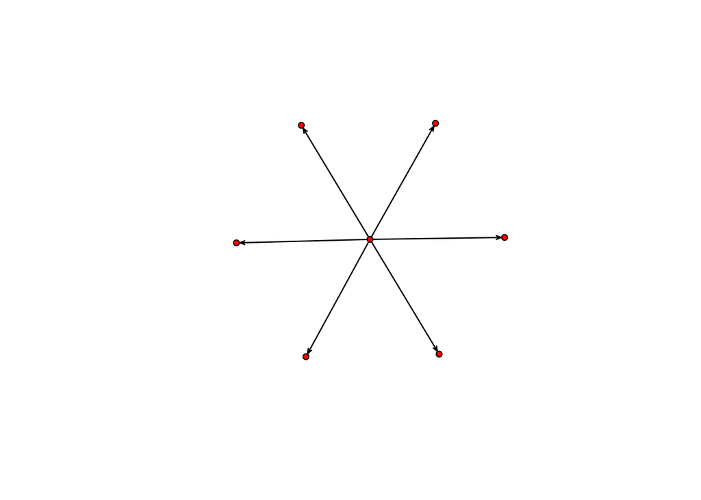

```r
library(network)
net <- network(df.alsace$edges,
               matrix.type="edgelist", ignore.eval=FALSE,
               directed = TRUE)

plot(net)
```

Cependant, pour faciliter les choses, `wikidataESR` propose une fonction adaptatée : `wdesr_ggplot_graph`

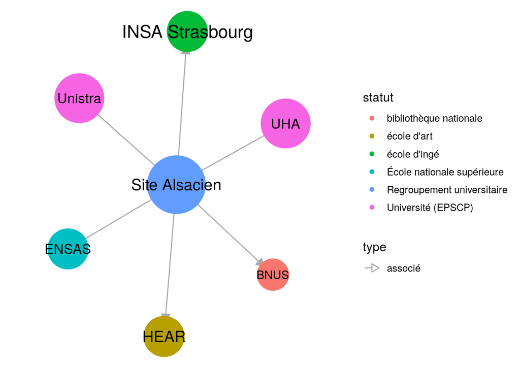

```r
wdesr_ggplot_graph(df.alsace)
```

### Deux en un

Pour facilier les choses, la fonction `wdesr_load_and_plot` permet de tout faire d’un coup :

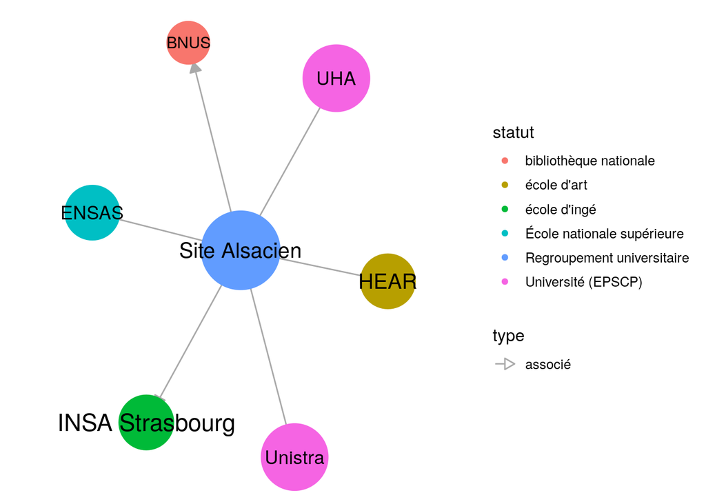

```r
wdesr_load_and_plot("Q61716176", c('composante','associé'), 1)
```

On peut observer que les deux images ne sont pas identiques : le processus de traçage des graphes est aléatoire. Il est ainsi parfois utile de tracer plusieurs fois un graphiques pour arriver à un résultat satisfaisant.

### Gestion du cache

Afin de ne pas avoir à retélécharger systématiquement les données, `wikidataESR` utilise un cache local. Il est possible de sauvegarder ce cache pour une utilisation future avec `wdesr_save_cache()`.

Il suffira ensuite de recharger le cache à la prochaine session pour ne pas retélécharger les données avec `wdesr_load_cache()`. Attention : en cas de modification des données sur wikidata, les données du cache local peuvent être périmées.

Il est enfin possible d’accéder directement au cache avec `wdesr_get_cache()`

## Pour aller plus loin

### Plus de profondeur

Il est souvent utile d’aller plus en profondeur pour explorer plus de relations. Cela se fait en modifiant l’argument `depth` :

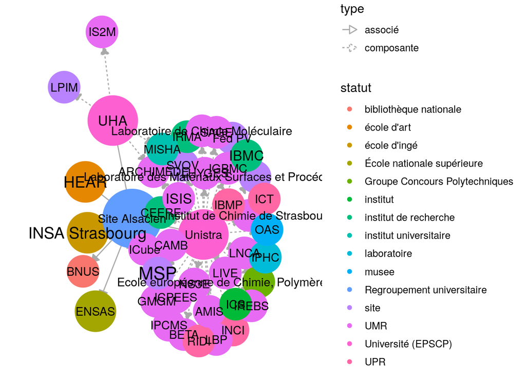

```r
wdesr_load_and_plot("Q61716176", c('composante','associé'), depth = 3)
```

### Plus de contrôle

Pour contrôler les graphiques, plusieurs paramètres sont disponibles :

#### Taille des noeuds

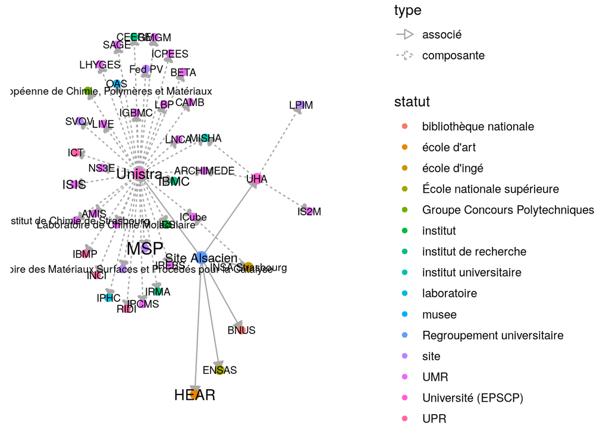

```r
wdesr_load_and_plot("Q61716176",c('composante','associé'), 3,
                    node_size = c(2,5), label_sizes = c(3,5),
                    arrow_gap = 0.0,
                    node_label = "alias", node_type = "text",
                    edge_label = FALSE)
```

#### Taille des textes

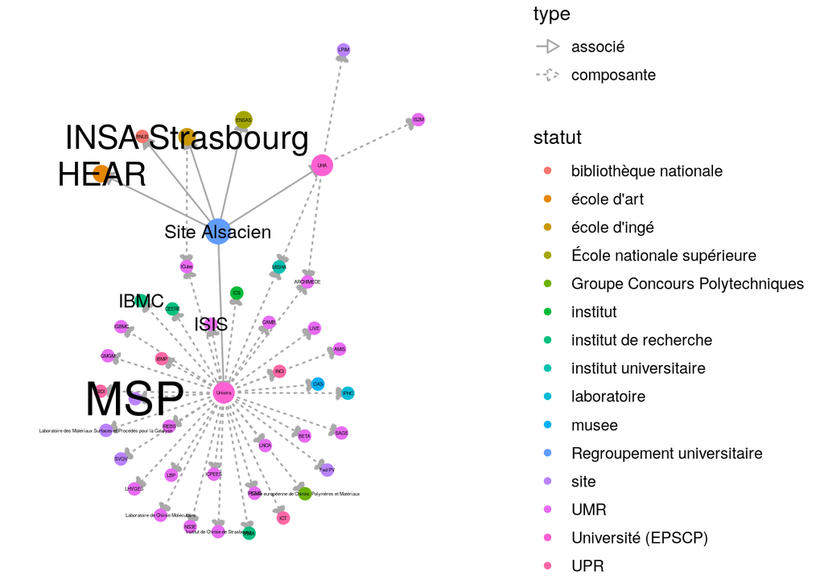

```r
wdesr_load_and_plot("Q61716176",c('composante','associé'), 3,
                    node_size = c(2,8), label_sizes = c(1,10),
                    arrow_gap = 0.0,
                    node_label = "alias", node_type = "text",
                    edge_label = FALSE)
```

#### Taille des textes

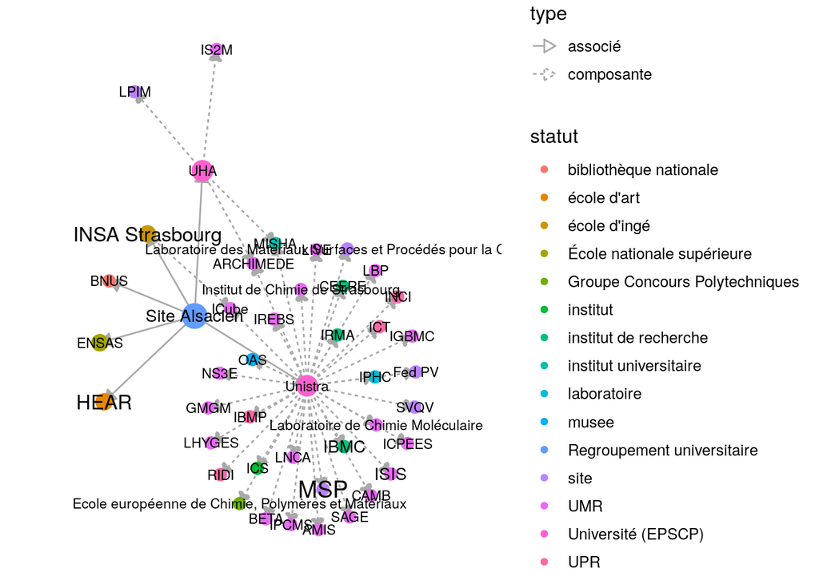

```r
wdesr_load_and_plot("Q61716176",c('composante','associé'), 3,
                    node_size = c(2,8), label_sizes = c(3,5),
                    arrow_gap = 0.0,
                    node_label = "alias", node_type = "text",
                    edge_label = FALSE)
```

#### Type des textes

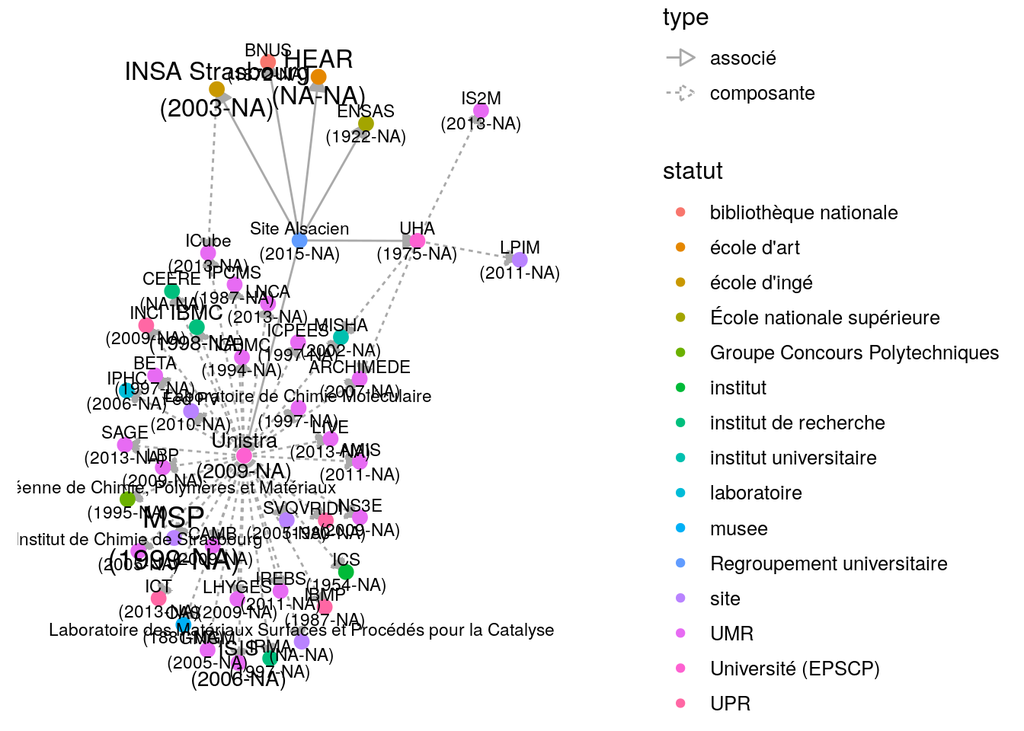

```r
wdesr_load_and_plot("Q61716176",c('composante','associé'), 3,
                    node_size = 3, label_sizes = c(3,5),
                    arrow_gap = 0.0,
                    node_label = "alias_date", node_type = "text",
                    edge_label = TRUE)
```

#### Type des noeuds

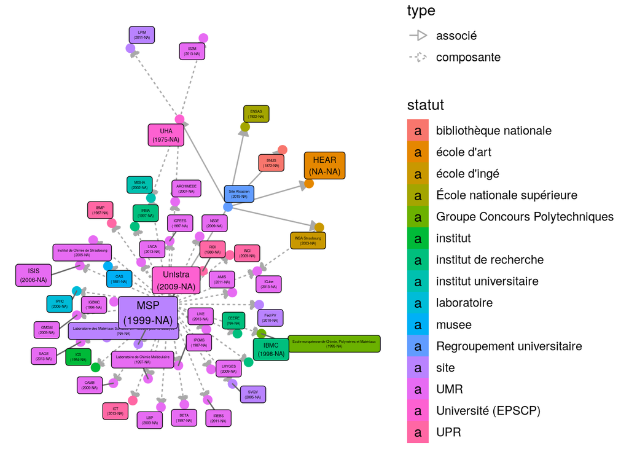

```r
wdesr_load_and_plot("Q61716176",c('composante','associé'), 3,
                    node_size = 3, label_sizes = c(1,3),
                    arrow_gap = 0.0,
                    node_label = "alias_date", node_type = "label_repel",
                    edge_label = FALSE)
```